# **DSA4155 - Problem Set 11**

**Submitted by:**

- Atasha Samantha T. Geronimo
- Zarinah Lindsay C. Gianan
- Cherelle Valkyrie R. Oyales
- Alecsandra Z. Villanueva

**Section:** 2DSA2  
**Date:** May 09, 2026

## Abstract

This assessment utilizes Market Basket Analysis (MBA) and Association Rule Mining on the 2022 Philippine Senatorial Elections dataset. By conceptualizing provinces as transactions and the top eight senatorial candidates as items, the research applies the Apriori algorithm to identify recurring voting patterns and political blocs. The analysis further quantifies senator-to-senator relationships using association rules, visualized in a lift heatmap. The results provide a data-driven perspective on coalition behavior and regional voting blocks, offering insights into the nature of candidate support across the Philippines.

## Setup

```python
# Data manipulation
import pandas as pd
import numpy as np

# Visualization
import matplotlib.pyplot as plt
import seaborn as sns

# Market Basket Analysis
from mlxtend.preprocessing import TransactionEncoder
from mlxtend.frequent_patterns import apriori, association_rules

print("The Libraries have been imported.")
print(f"Pandas version: {pd.__version__}")
print(f"NumPy version: {np.__version__}")
```

```
The Libraries have been imported.
Pandas version: 3.0.2
NumPy version: 2.4.4
```

# 1. Data Loading & Aggregation

## a) Data Loading

```python
# Load the senatorial election dataset
df = pd.read_csv("sen.csv")
# Display dataset shape
print("Dataset Shape:", df.shape)
# Display first 3 rows
df.head(3)
```

```
Dataset Shape: (105971, 71)
```

|  | Unnamed: 0 | region | province | city | brgy | precinct | total_votes | sen_1_afuang | sen_2_albani | sen_3_arranza | ... | sen_55_sahidulla | sen_56_sison | sen_57_teodoro | sen_58_trillanes | sen_59_tulfo | sen_60_valeros | sen_61_villanueva | sen_62_villar | sen_63_zubiaga | sen_64_zubiri |
| --- | --- | --- | --- | --- | --- | --- | --- | --- | --- | --- | --- | --- | --- | --- | --- | --- | --- | --- | --- | --- | --- |
| 0 | 0 | BARMM | BASILAN | AKBAR | CADDAYAN | 7080005 | 1320 | 2 | 32 | 0 | ... | 10 | 3 | 28 | 7 | 53 | 1 | 51 | 97 | 15 | 85 |
| 1 | 1 | BARMM | BASILAN | AKBAR | LINONGAN | 7080001 | 968 | 0 | 14 | 0 | ... | 8 | 0 | 61 | 0 | 34 | 0 | 2 | 34 | 0 | 39 |
| 2 | 2 | BARMM | BASILAN | AKBAR | LINONGAN | 7080002 | 513 | 0 | 9 | 0 | ... | 2 | 0 | 8 | 0 | 12 | 0 | 3 | 5 | 0 | 7 |

3 rows × 71 columns

> **Insight/s:**
> - The dataset contains **105,971 precinct-level records and 71 columns**.
> - Each row represents one precinct from the **2022 elections**.
> - The dataset includes vote counts for **64 senatorial candidates**.

## b) Extracting Senator Columns

```python
# Get all senator vote columns
sen_cols = [col for col in df.columns if col.startswith('sen_')]
print("Number of Senator Columns:", len(sen_cols))
print(sen_cols[:5])
```

```
Number of Senator Columns: 64
['sen_1_afuang', 'sen_2_albani', 'sen_3_arranza', 'sen_4_baguilat', 'sen_5_bailen']
```

```python
# Sum votes per province
province_votes = df.groupby('province')[sen_cols].sum()
# Display aggregated results
province_votes.head()
```

| province | sen_1_afuang | sen_2_albani | sen_3_arranza | sen_4_baguilat | sen_5_bailen | sen_6_balita | sen_7_barbo | sen_8_bautista | sen_9_belgica | sen_10_bello | ... | sen_55_sahidulla | sen_56_sison | sen_57_teodoro | sen_58_trillanes | sen_59_tulfo | sen_60_valeros | sen_61_villanueva | sen_62_villar | sen_63_zubiaga | sen_64_zubiri |
| --- | --- | --- | --- | --- | --- | --- | --- | --- | --- | --- | --- | --- | --- | --- | --- | --- | --- | --- | --- | --- | --- |
| ABRA | 2651 | 1440 | 1180 | 4943 | 1515 | 9302 | 1740 | 29610 | 3379 | 3341 | ... | 754 | 3252 | 41753 | 10637 | 60620 | 1441 | 47150 | 66591 | 1789 | 33614 |
| AGUSAN DEL NORTE | 5041 | 4044 | 4745 | 10533 | 4366 | 26471 | 17859 | 59368 | 22674 | 30060 | ... | 2169 | 8555 | 126577 | 25764 | 125579 | 2252 | 127322 | 167114 | 6046 | 170708 |
| AGUSAN DEL SUR | 6064 | 4364 | 4239 | 7121 | 4574 | 18337 | 3862 | 44812 | 9553 | 7558 | ... | 1981 | 6253 | 114525 | 24802 | 124860 | 2870 | 123189 | 132265 | 5884 | 146415 |
| AKLAN | 5035 | 3443 | 2819 | 26120 | 3323 | 36467 | 3032 | 71517 | 8379 | 7109 | ... | 1653 | 13285 | 54279 | 76221 | 154611 | 2185 | 133160 | 117005 | 10878 | 112233 |
| ALBAY | 13236 | 14118 | 9453 | 109537 | 12340 | 47991 | 9479 | 111431 | 19970 | 16512 | ... | 4931 | 32786 | 70692 | 288164 | 291097 | 5769 | 211067 | 181457 | 26481 | 212824 |

5 rows × 64 columns

> **Insight/s:**
> - Votes were successfully aggregated into **90 province-level transactions**.
> - **Province-level aggregation** helps identify broader regional voting behavior.
> - Candidates like Sen. Padilla, Sen. Tulfo, Sen. Legarda, Sen. Villar, and Sen. Gatchalian consistently appeared among the top provincial vote-getters.

## c) Top 8 Senators

```python
transactions = []
# Loop through each province
for province, row in province_votes.iterrows():

    # Get top 8 senators by votes
    top8 = row.sort_values(ascending=False).head(8)

    # Extract senator last names only
    senators = [col.replace('sen_', '').split('_')[-1] for col in top8.index]
    transactions.append(senators)

# Display sample transactions
print("Sample Transactions:")
for t in transactions[:5]:
    print(t)

print("\nTotal Transactions:", len(transactions))
```

```
Sample Transactions:
['padilla', 'estrada', 'villar', 'binay', 'tulfo', 'ejercito', 'legarda', 'gatchalian']
['padilla', 'zubiri', 'legarda', 'villar', 'gatchalian', 'villanueva', 'teodoro', 'tulfo']
['padilla', 'zubiri', 'legarda', 'cayetano', 'villar', 'gatchalian', 'ejercito', 'tulfo']
['legarda', 'tulfo', 'hontiveros', 'villanueva', 'escudero', 'padilla', 'gatchalian', 'villar']
['escudero', 'hontiveros', 'tulfo', 'trillanes', 'lima', 'legarda', 'cayetano', 'diokno']

Total Transactions: 90
```

> **Insight/s:**
> - Each transaction contains the Top 8 senators per province.
> - Several provinces showed recurring combinations of:
>   - Padilla
>   - Tulfo
>   - Legarda
>   - Villar
>   - Gatchalian
> - This already suggests the presence of strong nationwide political alliances.

# 2. Frequent Itemset Mining

> One-hot encoding converts transactions into binary format.

## a) Data Transformation

```python
# Initialize TransactionEncoder
te = TransactionEncoder()

# Transform transactions into one-hot encoded array
te_array = te.fit(transactions).transform(transactions)

# Convert to DataFrame
basket_df = pd.DataFrame(te_array, columns=te.columns_)

basket_df.head()
```

|  | baguilat | bautista | binay | cayetano | diokno | ejercito | eleazar | escudero | estrada | gadon | ... | padilla | piñol | roque | sahidulla | teodoro | trillanes | tulfo | villanueva | villar | zubiri |
| --- | --- | --- | --- | --- | --- | --- | --- | --- | --- | --- | --- | --- | --- | --- | --- | --- | --- | --- | --- | --- | --- |
| 0 | False | False | True | False | False | True | False | False | True | False | ... | True | False | False | False | False | False | True | False | True | False |
| 1 | False | False | False | False | False | False | False | False | False | False | ... | True | False | False | False | True | False | True | True | True | True |
| 2 | False | False | False | True | False | True | False | False | False | False | ... | True | False | False | False | False | False | True | False | True | True |
| 3 | False | False | False | False | False | False | False | True | False | False | ... | True | False | False | False | False | False | True | True | True | False |
| 4 | False | False | False | True | True | False | False | True | False | False | ... | False | False | False | False | False | True | True | False | False | False |

5 rows × 25 columns

> **Insight/s:**
> - True means the senator appears in a province's Top 8.

## b) Frequent Itemset Generation (Apriori)

```python
# Generate frequent itemsets
freq_itemsets = apriori(basket_df,
                        min_support=0.3,
                        use_colnames=True)

# Add itemset size column
freq_itemsets['itemset_size'] = freq_itemsets['itemsets'].apply(len)

# Display total number of frequent itemsets
print("Total Frequent Itemsets:", len(freq_itemsets))

freq_itemsets.head()
```

```
Total Frequent Itemsets: 191
```

|  | support | itemsets | itemset_size |
| --- | --- | --- | --- |
| 0 | 0.722222 | frozenset({cayetano}) | 1 |
| 1 | 0.555556 | frozenset({escudero}) | 1 |
| 2 | 0.377778 | frozenset({estrada}) | 1 |
| 3 | 0.777778 | frozenset({gatchalian}) | 1 |
| 4 | 0.977778 | frozenset({legarda}) | 1 |

## c) Itemset: Pruning

```python
# Filter 2-itemsets
itemsets_2 = freq_itemsets[freq_itemsets['itemset_size'] == 2]

itemsets_2.sort_values(by='support', ascending=False).head(10)
```

|  | support | itemsets | itemset_size |
| --- | --- | --- | --- |
| 35 | 0.933333 | frozenset({legarda, tulfo}) | 2 |
| 34 | 0.911111 | frozenset({legarda, padilla}) | 2 |
| 39 | 0.888889 | frozenset({padilla, tulfo}) | 2 |
| 41 | 0.766667 | frozenset({padilla, villar}) | 2 |
| 37 | 0.755556 | frozenset({legarda, villar}) | 2 |
| 28 | 0.755556 | frozenset({gatchalian, legarda}) | 2 |
| 44 | 0.744444 | frozenset({villar, tulfo}) | 2 |
| 29 | 0.744444 | frozenset({gatchalian, padilla}) | 2 |
| 30 | 0.744444 | frozenset({gatchalian, tulfo}) | 2 |
| 12 | 0.711111 | frozenset({legarda, cayetano}) | 2 |

> **Insight/s:**
> - The pair (**Legarda, Tulfo**) had the **highest support value of 0.9333**. This means the pair appeared together in approximately **93% of provinces**.
> - Other highly frequent pairs included:
>   - (Legarda, Padilla)
>   - (Padilla, Tulfo)
>   - (Padilla, Villar)

```python
# Filter 3-itemsets
itemsets_3 = freq_itemsets[freq_itemsets['itemset_size'] == 3]

itemsets_3.sort_values(by='support', ascending=False).head(10)
```

|  | support | itemsets | itemset_size |
| --- | --- | --- | --- |
| 96 | 0.866667 | frozenset({legarda, padilla, tulfo}) | 3 |
| 98 | 0.744444 | frozenset({legarda, padilla, villar}) | 3 |
| 106 | 0.733333 | frozenset({tulfo, padilla, villar}) | 3 |
| 87 | 0.722222 | frozenset({gatchalian, legarda, padilla}) | 3 |
| 88 | 0.722222 | frozenset({gatchalian, legarda, tulfo}) | 3 |
| 101 | 0.722222 | frozenset({villar, legarda, tulfo}) | 3 |
| 91 | 0.711111 | frozenset({gatchalian, padilla, tulfo}) | 3 |
| 57 | 0.666667 | frozenset({legarda, cayetano, tulfo}) | 3 |
| 56 | 0.655556 | frozenset({legarda, cayetano, padilla}) | 3 |
| 61 | 0.622222 | frozenset({padilla, cayetano, tulfo}) | 3 |

> **Insight/s:**
> - The combination (**Legarda, Padilla, Tulfo**) achieved the highest 3-itemset support at 0.8667.
> - These combinations of candidates consistently appeared together across provinces, suggesting a strong voting bloc.

## d) Highest Support Analysis

```python
# Get highest support pair
top_pair = itemsets_2.sort_values(by='support', ascending=False).iloc[0]

print(top_pair)
```

```
support                            0.933333
itemsets        frozenset({legarda, tulfo})
itemset_size                              2
Name: 35, dtype: object
```

### Which 2-senator pair has the highest support? What does this tell you politically?

With **0.9333**, **Sen. Legarda and Sen Tulfo** **had the highest support value**. This means they appeared together most often in the Top 8 Senators across about **93% of provinces**. Politically, this showcases their nationwide appeal to voters across different regions, reflecting **strong coalition influence** and widespread popularity during the 2022 elections.

# 3. Association Rule Generation

## a) Generation of Association Rules

```python
# Fix frozenset encoding issue
freq_itemsets['itemsets'] = freq_itemsets['itemsets'].apply(
    lambda x: frozenset(str(i) for i in x)
)

# Generate association rules
rules = association_rules(
    freq_itemsets,
    num_itemsets=len(freq_itemsets),
    metric='confidence',
    min_threshold=0.7
)

# Select important columns
rules = rules[['antecedents',
               'consequents',
               'support',
               'confidence',
               'lift']]

# Sort by lift
rules = rules.sort_values(by='lift', ascending=False)

rules.head(10)
```

|  | antecedents | consequents | support | confidence | lift |
| --- | --- | --- | --- | --- | --- |
| 940 | frozenset({villanueva, legarda, padilla, tulfo}) | frozenset({escudero, gatchalian}) | 0.311111 | 0.800000 | 1.714286 |
| 952 | frozenset({legarda, padilla, villanueva}) | frozenset({escudero, gatchalian, tulfo}) | 0.311111 | 0.800000 | 1.714286 |
| 733 | frozenset({legarda, padilla, villanueva}) | frozenset({escudero, gatchalian}) | 0.311111 | 0.800000 | 1.714286 |
| 945 | frozenset({villanueva, gatchalian, legarda, tu... | frozenset({escudero, padilla}) | 0.311111 | 0.823529 | 1.684492 |
| 955 | frozenset({gatchalian, legarda, villanueva}) | frozenset({escudero, padilla, tulfo}) | 0.311111 | 0.823529 | 1.684492 |
| 735 | frozenset({gatchalian, legarda, villanueva}) | frozenset({escudero, padilla}) | 0.311111 | 0.823529 | 1.684492 |
| 964 | frozenset({padilla, villanueva}) | frozenset({escudero, gatchalian, legarda, tulfo}) | 0.311111 | 0.777778 | 1.666667 |
| 408 | frozenset({padilla, villanueva}) | frozenset({escudero, gatchalian}) | 0.311111 | 0.777778 | 1.666667 |
| 783 | frozenset({villanueva, padilla, tulfo}) | frozenset({escudero, gatchalian}) | 0.311111 | 0.777778 | 1.666667 |
| 956 | frozenset({villanueva, padilla, tulfo}) | frozenset({escudero, gatchalian, legarda}) | 0.311111 | 0.777778 | 1.666667 |

## b) Rule Filtering (Lift & Confidence)

```python
# Filter strong rules
strong_rules = rules[
    (rules['lift'] > 1.2) &
    (rules['confidence'] > 0.75)
]

print("Number of Strong Rules:", len(strong_rules))

strong_rules.head(10)
```

```
Number of Strong Rules: 82
```

|  | antecedents | consequents | support | confidence | lift |
| --- | --- | --- | --- | --- | --- |
| 940 | frozenset({villanueva, legarda, padilla, tulfo}) | frozenset({escudero, gatchalian}) | 0.311111 | 0.800000 | 1.714286 |
| 952 | frozenset({legarda, padilla, villanueva}) | frozenset({escudero, gatchalian, tulfo}) | 0.311111 | 0.800000 | 1.714286 |
| 733 | frozenset({legarda, padilla, villanueva}) | frozenset({escudero, gatchalian}) | 0.311111 | 0.800000 | 1.714286 |
| 945 | frozenset({villanueva, gatchalian, legarda, tu... | frozenset({escudero, padilla}) | 0.311111 | 0.823529 | 1.684492 |
| 955 | frozenset({gatchalian, legarda, villanueva}) | frozenset({escudero, padilla, tulfo}) | 0.311111 | 0.823529 | 1.684492 |
| 735 | frozenset({gatchalian, legarda, villanueva}) | frozenset({escudero, padilla}) | 0.311111 | 0.823529 | 1.684492 |
| 964 | frozenset({padilla, villanueva}) | frozenset({escudero, gatchalian, legarda, tulfo}) | 0.311111 | 0.777778 | 1.666667 |
| 408 | frozenset({padilla, villanueva}) | frozenset({escudero, gatchalian}) | 0.311111 | 0.777778 | 1.666667 |
| 783 | frozenset({villanueva, padilla, tulfo}) | frozenset({escudero, gatchalian}) | 0.311111 | 0.777778 | 1.666667 |
| 956 | frozenset({villanueva, padilla, tulfo}) | frozenset({escudero, gatchalian, legarda}) | 0.311111 | 0.777778 | 1.666667 |

> **Insight/s:**
> - A total of 82 strict rules remained after filtering using:
>   - **Lift > 1.2**
>   - **Confidence > 0.75**
> - The remaining rules represent highly reliable senator associations.
> - The strictest rules involved candidates from dominant national political coalitions.

```python
# Get highest lift rule
best_rule = strong_rules.iloc[0]

print(best_rule)
```

```
antecedents    frozenset({villanueva, legarda, padilla, tulfo})
consequents                   frozenset({escudero, gatchalian})
support                                                0.311111
confidence                                                  0.8
lift                                                   1.714286
Name: 940, dtype: object
```

### Identify the rule with the highest lift. Write one sentence interpreting what this rule means in the context of the 2022 elections.

- **Support = 0.3111**
- **Confidence = 0.80**
- **Lift - 1.7143**

This rule suggests that provinces where Padilla, Villanueva, and Legarda appeared together in the Top 8 senators were highly likely to also include Escudero and Gatchalian. The high lift values indicate a strong positive association among these candidates, reflecting the voting pattern during the 2022 elections.

# 4. Lift Heatmap

## a) Rule Filtering (Single-Item Associations)

```python
# Filter single antecedent and consequent rules
s_rules = rules[
    (rules['antecedents'].apply(len) == 1) &
    (rules['consequents'].apply(len) == 1)
].copy()

# Convert frozensets to strings
s_rules['ant_str'] = s_rules['antecedents'].apply(lambda x: list(x)[0])
s_rules['con_str'] = s_rules['consequents'].apply(lambda x: list(x)[0])

s_rules.head()
```

|  | antecedents | consequents | support | confidence | lift | ant_str | con_str |
| --- | --- | --- | --- | --- | --- | --- | --- |
| 16 | frozenset({villanueva}) | frozenset({escudero}) | 0.377778 | 0.850000 | 1.530000 | villanueva | escudero |
| 27 | frozenset({villanueva}) | frozenset({gatchalian}) | 0.388889 | 0.875000 | 1.125000 | villanueva | gatchalian |
| 20 | frozenset({estrada}) | frozenset({villar}) | 0.322222 | 0.852941 | 1.096639 | estrada | villar |
| 49 | frozenset({zubiri}) | frozenset({villar}) | 0.377778 | 0.850000 | 1.092857 | zubiri | villar |
| 12 | frozenset({escudero}) | frozenset({gatchalian}) | 0.466667 | 0.840000 | 1.080000 | escudero | gatchalian |

### How many rules remain after filtering?

After filtering for lift > 1.2 and confidence > 0.75, **82 strong association rules remained**.

## b) Matrix Construction and Plotting

```python
# Create list of senators
items = sorted(set(s_rules['ant_str']) | set(s_rules['con_str']))

# Initialize matrix with baseline lift of 1.0
lift_matrix = pd.DataFrame(1.0, index=items, columns=items)

# Populate lift values
for _, row in s_rules.iterrows():
    lift_matrix.loc[row['ant_str'], row['con_str']] = row['lift']

lift_matrix.head()
```

|  | cayetano | escudero | estrada | gatchalian | legarda | padilla | tulfo | villanueva | villar | zubiri |
| --- | --- | --- | --- | --- | --- | --- | --- | --- | --- | --- |
| cayetano | 1.000000 | 1.0 | 1.0 | 1.028571 | 1.006993 | 0.989011 | 0.982111 | 1.0 | 0.929670 | 1.0 |
| escudero | 1.024615 | 1.0 | 1.0 | 1.080000 | 1.022727 | 0.942857 | 1.046512 | 1.0 | 1.000000 | 1.0 |
| estrada | 1.000000 | 1.0 | 1.0 | 1.000000 | 1.022727 | 1.071429 | 0.954172 | 1.0 | 1.096639 | 1.0 |
| gatchalian | 1.028571 | 1.0 | 1.0 | 1.000000 | 0.993506 | 1.025510 | 1.001661 | 1.0 | 0.973469 | 1.0 |
| legarda | 1.006993 | 1.0 | 1.0 | 0.993506 | 1.000000 | 0.998377 | 0.998943 | 1.0 | 0.993506 | 1.0 |

> **Insight/s:**
> - Lift values **below 1.0** highlight segmented voter bases.
> - This suggests that voters who prioritized one specific political brand or "name" were statistically less likely to cross over to the other, indicating distinct regional or ideological niches.
> - Lift **values at or greater than 1.0** for top-ranking candidates (like Tulfo or Legarda) indicate "independent strength."
> - These candidates appeared consistently across various provincial ballots regardless of which other senators were chosen, reflecting a truly national, cross-party appeal.

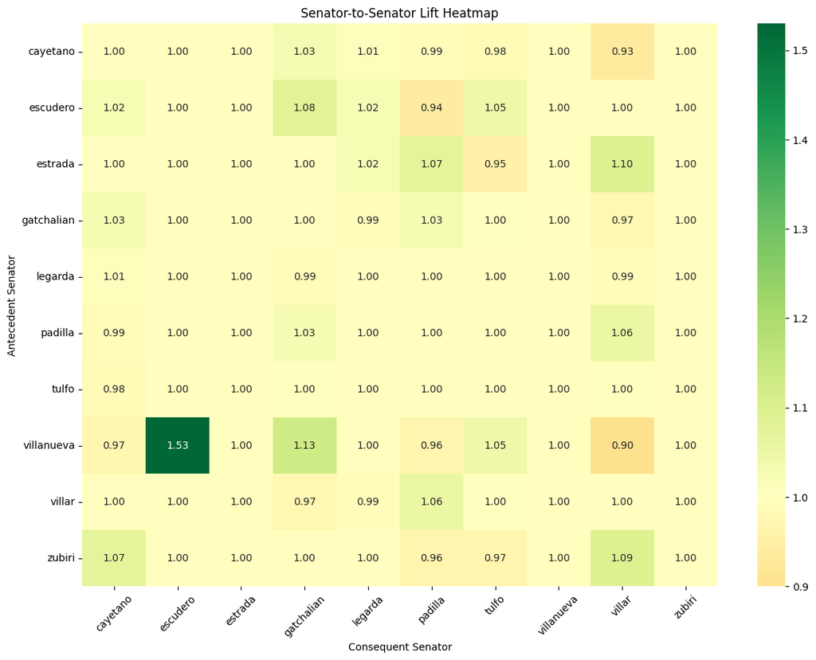

```python
# Plot heatmap
plt.figure(figsize=(14, 10))

sns.heatmap(lift_matrix,
            cmap='RdYlGn',
            center=1.0,
            annot=True,
            fmt='.2f')

plt.title("Senator-to-Senator Lift Heatmap")

plt.xlabel("Consequent Senator")
plt.ylabel("Antecedent Senator")

plt.xticks(rotation=45)
plt.yticks(rotation=0)

plt.show()
```

> **Insight/s:**
> - The heatmap shows senator-to-senator association strengths using lift values.
> - Most senator pairs had lift values close to 1.0, indicating neutral relationships.
> - The strongest positive association was between Villanueva → Escudero (1.53).

### Identify (a) one pair with the strongest positive association (lift >> 1), and (b) one pair with a weak or negative association (lift ≈ 1 or < 1).

(a) **Villanueva-Escudero** showed the **strongest positive associations** in the heatmap with a **lift value of 1.53**. This indicates that provinces voting for Villanueva were also significantly more likely to include Escudero among their Top 8 senators.

(b) On the other hand, **Villar-Villanueva** indicated a **weaker association** with a **lift value of 0.90**. A lift below 1 suggests a weaker-than-expected relationship, meaning Villanueva's presence in a province's Top 8 did not strongly imply Villar's appearance.

# 5. Interpretation

## a) Top 3 Rules by lift

```python
# Display top 3 rules
top3 = strong_rules.head(3)

top3
```

|  | antecedents | consequents | support | confidence | lift |
| --- | --- | --- | --- | --- | --- |
| 940 | frozenset({villanueva, legarda, padilla, tulfo}) | frozenset({escudero, gatchalian}) | 0.311111 | 0.8 | 1.714286 |
| 952 | frozenset({legarda, padilla, villanueva}) | frozenset({escudero, gatchalian, tulfo}) | 0.311111 | 0.8 | 1.714286 |
| 733 | frozenset({legarda, padilla, villanueva}) | frozenset({escudero, gatchalian}) | 0.311111 | 0.8 | 1.714286 |

In provinces where the combination of **Sen. Padilla, Sen. Villanueva, Sen. Legarda and often Sen. Tulfo** appears in the Top 8, there is an 80% (confidence) chance that voters also chose Sen. Escudero and Sen. Gatchalian. This specific group of senators appeared together in the Top 8 rankings of 31.1% of all provinces. Given the lift value of 1.71, this likely did not occur by chance.

## In 3–5 sentences, describe the voting bloc pattern you observe from the rules and heatmap. Do the associations align with the known political coalitions from 2022 (UniTeam vs. opposition)?

The association rules reveal that several senatorial candidates appeared together consistently across provinces.

Candidates such as **Sen. Tulfo, Sen. Padilla, Sen. Legarda, Sen. Villar, Sen. Gatchalian, and Sen. Escudero** frequently formed **highly associated combinations**, suggesting that voters often supported groups of candidates rather than selecting independently.

Despite belonging to different parties, most of these candidates appeared together on the UniTeam slate, led by BongBong Marcos and Sara Duterte, giving the public the impression that they were part of a single team.

## Name one limitation of using province-level aggregation for this MBA analysis. How might results differ if you used municipality-level transactions instead?

The main limitation is **aggregating votes to the province level**, which disregards voting differences within individuals or smaller groups in that area. By treating an entire province as a single transaction, the analysis assumes a smooth transition of the unique political leanings of different cities or rural districts.

If municipality-level transactions were used instead, the analysis could reveal more detailed, localized voting alliances, potentially uncovering stronger or more distinct association patterns among candidates.

# 6. References

Admin. (2022, May 10). Comelec election results 2022: President, vice-president, senators. PRC Board. https://www.prcboard.com/2022-election-result-philippines-comelec-voting-tally-for-president-vice-president-and-senators

Figshare. (2022). 2022 Presidential Elections Data [Data set]. Figshare.  
https://figshare.com/articles/dataset/2022_presidential_elections_data/19755469

OpenAI. (2026).  
ChatGPT (GPT-5.3). https://chat.openai.com/